> 07 Oct 2017 » matplotlib, visualization

# Visualization with Python - matplotlib ②

## matplotlib ②

#### 이번 포스팅에서는 다음 plot을 알아보자.

- 바 차트 (bar chart)
- 줄기 플롯 (stem plot)
- pie chart
- 히스토그램 (histogram)
- 스캐터 플롯 (scatter plot)
- 컨투어 플롯 (contour plot)
- 서피스 플롯 (surface plot)

### Bar chart

- x, y 데이터 중 하나가 카테고리 값인 경우에는 `bar` 명령과 `barh` 명령으로 바 차트(bar chart) 시각화를 할 수 있다.
- 가로 방향으로 바 차트를 그리려면 `barh` 명령을 사용한다.
- document는 다음을 참고하자.
  - http://matplotlib.org/api/pyplot_api.html#matplotlib.pyplot.bar
  - http://matplotlib.org/api/pyplot_api.html#matplotlib.pyplot.barh

#### 바 차트 작성시 주의점은 첫번째 인수인 `left` 가 x축에서 바(bar)의 왼쪽 변의 위치를 나타낸다는 점이다.

```python
import matplotlib as mpl
import matplotlib.pylab as plt
import numpy as np
%matplotlib inline
```

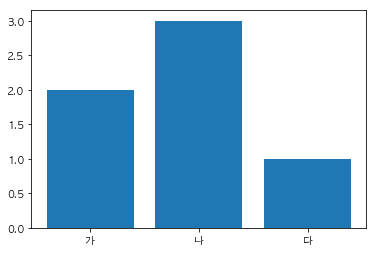

```python
# 한글을 사용하기 위해 폰트 지정
mpl.rc('font', family='AppleGothic')
# 한글 폰트지정을 할 때, axes는 영향을 받지 않도록 아래 코드도 실행시켜야 한다.
mpl.rc('axes', unicode_minus=False)

y = [2, 3, 1]
x = np.arange(len(y))
xlabel = [u'가', u'나', u'다']

# plt.bar → 세로 막대
plt.bar(x, y)
plt.xticks(x, xlabel)
plt.show()
```

#### `xerr` 인수나 `yerr` 인수를 지정하면 에러 바(error bar)를 추가할 수 있다.

- 여기에서 `alpha`는 투명도를 지정한다. 0이면 완전 투명, 1이면 완전 불투명이다.

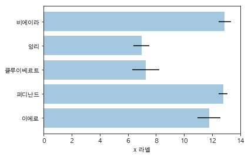

```python
people = (u'이에로', u'퍼디난드', u'클루이베르트', u'앙리', u'비에이라')
y_pos = np.arange(len(people))
performance = 3 + 10 * np.random.rand(len(people))
error = np.random.rand(len(people))

# plt.barh → 가로 막대
plt.barh(y_pos, performance, xerr=error, align='center', alpha=0.4)
plt.yticks(y_pos, people)
plt.xlabel(u'x 라벨')
plt.show()
```

#### 두 개 이상의 바 차트를 한번에 그리는 경우도 있다.

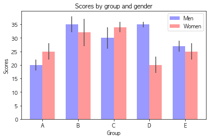

```python
n_groups = 5
means_men = (20, 35, 30, 35, 27)
std_men = (2, 3, 4, 1, 2)
means_women = (25, 32, 34, 20, 25)
std_women = (3, 5, 2, 3, 3)

fig, ax = plt.subplots()

index = np.arange(n_groups)
bar_width = 0.35

opacity = 0.4
error_config = {'ecolor': '0.3'}

rects1 = plt.bar(index, means_men, bar_width,
                 alpha=opacity,
                 color='b',
                 yerr=std_men,
                 error_kw=error_config,
                 label='Men',
                 align='edge')

rects2 = plt.bar(index + bar_width, means_women, bar_width,
                 alpha=opacity,
                 color='r',
                 yerr=std_women,
                 error_kw=error_config,
                 label='Women',
                 align='edge')

plt.xlabel('Group')
plt.ylabel('Scores')
plt.title('Scores by group and gender')
plt.xticks(index + bar_width, ('A', 'B', 'C', 'D', 'E'))
plt.legend()
plt.tight_layout()
plt.show()
```

#### 또는 `bottom` 인수로 바의 위치를 조정하여 겹친 바 차트(stacked bar chart)도 그릴 수 있다.

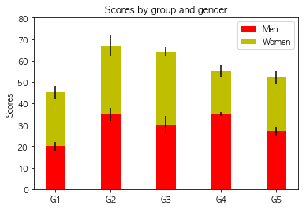

```python
N = 5
menMeans = (20, 35, 30, 35, 27)
womenMeans = (25, 32, 34, 20, 25)
menStd = (2, 3, 4, 1, 2)
womenStd = (3, 5, 2, 3, 3)
ind = np.arange(N)    # the x locations for the groups
width = 0.35       # the width of the bars: can also be len(x) sequence

p1 = plt.bar(ind, menMeans, width, color='r', yerr=menStd)
p2 = plt.bar(ind, womenMeans, width, color='y',
             bottom=menMeans, yerr=womenStd)

plt.ylabel('Scores')
plt.title('Scores by group and gender')
plt.xticks(ind, ('G1', 'G2', 'G3', 'G4', 'G5'))
plt.yticks(np.arange(0, 81, 10))
plt.legend((p1[0], p2[0]), ('Men', 'Women'))
plt.show()
```

### Stem plot

- 바 차트와 유사하지만 폭(width)이 없는 스템 플롯(stem plot)도 있다.
- 주로 이산 확률 함수나 자기상관관계(auto-correlation)를 묘사할 때 사용된다.
- documents는 아래서 확인하자.
  - http://matplotlib.org/api/pyplot_api.html#matplotlib.pyplot.stem

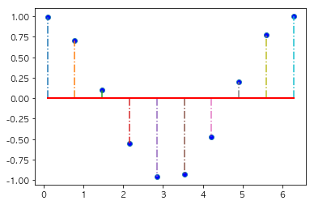

```python
x = np.linspace(0.1, 2 * np.pi, 10)

markerline, stemlines, baseline = plt.stem(x, np.cos(x), '-.')

plt.setp(markerline, 'markerfacecolor', 'b')
plt.setp(baseline, 'color', 'r', 'linewidth', 2)
plt.show()
```

### pie chart

- 카테고리 별 값의 상대적인 비교를 해야 할 때는 `pie`으로 pie chart를 그려야 한다.
- document
  - http://matplotlib.org/api/pyplot_api.html#matplotlib.pyplot.pie

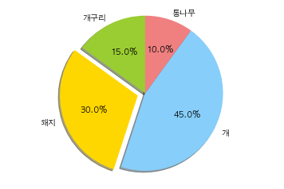

```python
labels = u'개구리', u'돼지', u'개', u'통나무'

# 합은 100
sizes = [15, 30, 45, 10]
colors = ['yellowgreen', 'gold', 'lightskyblue', 'lightcoral']

# 파이를 잘라서 떨어뜨리는 간격 조정
explode = (0, 0.1, 0, 0)

plt.pie(sizes, explode=explode, labels=labels, colors=colors,
        autopct='%1.1f%%', shadow=True, startangle=90)
plt.axis('equal')
plt.show()
```

### Histogram

- `hist`로 히스토그램을 그릴 수 있다.
- `hist`는 `bins` 인수로 데이터 집계 구간을 받는다.
- 또한 반환값으로 데이터 집계 결과를 반환해주므로 이 결과를 다른 코드에서 사용할 수도 있다.
- documents
  - http://matplotlib.org/api/pyplot_api.html#matplotlib.pyplot.hist

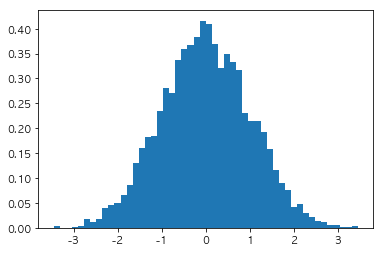

```python
x = np.random.randn(5000)

# 50개 구간으로 나눈다. → bins 값은 51개
## normed=True → 히스토그램 면접의 합 = 1로 normalizing
arrays, bins, patches = plt.hist(x, bins=50, normed=True)
plt.show()
```

### Scatter plot

- 두 개의 데이터 집합의 상관관계를 살펴보려면 `scatter` 명령으로 스캐터 플롯을 그린다.
- documents
  - http://matplotlib.org/api/pyplot_api.html#matplotlib.pyplot.scatter

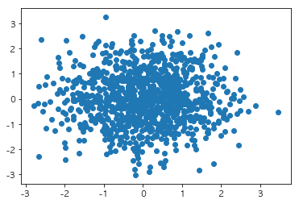

```python
X = np.random.normal(0,1,1024)
Y = np.random.normal(0,1,1024)

plt.scatter(X,Y)
plt.show()
```

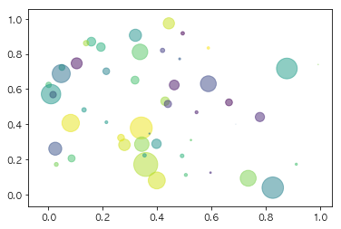

```python
N = 50
x = np.random.rand(N)
y = np.random.rand(N)

colors = np.random.rand(N)
area = np.pi * (15 * np.random.rand(N))**2

plt.scatter(x, y, s=area, c=colors, alpha=0.5)
plt.show()
```

### Imshow

#### 지금까지는 1개 또는 2개의 1차원 자료에 대한 시각화를 살펴보았다.

- 이제는 행과 열을 가진 2차원 데이터의 시각화에 대해 알아보자.

#### 예를 들어 화상(image) 데이터는 전형적인 2차원 자료이다.

- 가장 간단한 2차원 자료 시각화 방법은 `imshow` 명령을 써서 2차원 자료 자체를 각 위치의 명암으로 표시하는 것이다.
- 자료의 시각화를 돕기위해 다양한 2차원 인터폴레이션을 지원한다.
- documents
  - http://matplotlib.org/api/pyplot_api.html#matplotlib.pyplot.imshow

```python
from sklearn.datasets import load_digits
digits = load_digits()
X = digits.images[0]
X
```

```
array([[  0.,   0.,   5.,  13.,   9.,   1.,   0.,   0.],
       [  0.,   0.,  13.,  15.,  10.,  15.,   5.,   0.],
       [  0.,   3.,  15.,   2.,   0.,  11.,   8.,   0.],
       [  0.,   4.,  12.,   0.,   0.,   8.,   8.,   0.],
       [  0.,   5.,   8.,   0.,   0.,   9.,   8.,   0.],
       [  0.,   4.,  11.,   0.,   1.,  12.,   7.,   0.],
       [  0.,   2.,  14.,   5.,  10.,  12.,   0.,   0.],
       [  0.,   0.,   6.,  13.,  10.,   0.,   0.,   0.]])
```

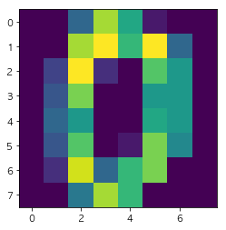

```python
plt.imshow(X, interpolation='nearest');
plt.grid(False)
plt.show()
```

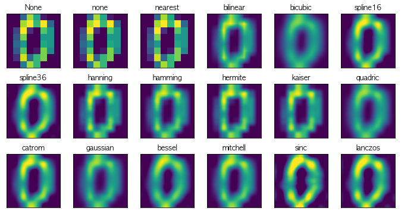

```python
methods = [None, 'none', 'nearest', 'bilinear', 'bicubic', 'spline16',
           'spline36', 'hanning', 'hamming', 'hermite', 'kaiser', 'quadric',
           'catrom', 'gaussian', 'bessel', 'mitchell', 'sinc', 'lanczos']

# subplots의 fig을 받고, 각 subplot axes의 기본 설정을 받아서 저장
fig, axes = plt.subplots(3, 6, figsize=(12, 6), subplot_kw={'xticks': [], 'yticks': []})
fig.subplots_adjust(hspace=0.3, wspace=0.05)

for ax, interp_method in zip(axes.flat, methods):
    ax.imshow(X, interpolation=interp_method)
    ax.set_title(interp_method)
plt.show()
```

### contour plot (등고선)

- 3차원 자료를 시각화하는 방법이다.
- `contour` 혹은 `contourf`을 사용한다.
- documents
  - http://matplotlib.org/api/pyplot_api.html#matplotlib.pyplot.contour
  - http://matplotlib.org/api/pyplot_api.html#matplotlib.pyplot.contourf

```python
def f(x, y):
    return (1 - x / 2 + x ** 5 + y ** 3) * np.exp(-x ** 2 -y ** 2)

n = 256
x = np.linspace(-3, 3, n)
y = np.linspace(-3, 3, n)

## meshgrid를 활용하여 x,y의 shape을 합쳐준다.(broadcasting)
XX, YY = np.meshgrid(x, y)
ZZ = f(XX, YY)
```

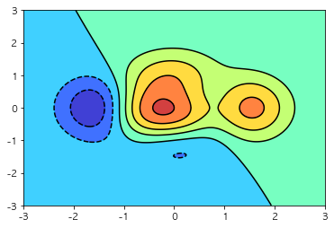

```python
plt.contourf(XX, YY, ZZ, alpha=.75, cmap='jet')
plt.contour(XX, YY, ZZ, colors='black', linewidth=.5)
plt.show()
```

### 3D 서피스 플롯

- 3차원 플롯은 등고선 플롯과 달리 `Axes3D`라는 3차원 전용 axes를 생성하여 입체적으로 표시한다.
- `plot_wireframe`, `plot_surface`을 사용한다.
- documents
  - http://matplotlib.org/mpl_toolkits/mplot3d/api.html#mpl_toolkits.mplot3d.axes3d.Axes3D.plot_wireframe
  - http://matplotlib.org/mpl_toolkits/mplot3d/api.html#mpl_toolkits.mplot3d.axes3d.Axes3D.plot_surface

```python
from mpl_toolkits.mplot3d import Axes3D

X = np.arange(-4, 4, 0.25)
Y = np.arange(-4, 4, 0.25)

XX, YY = np.meshgrid(X, Y)
RR = np.sqrt(XX**2 + YY**2)
ZZ = np.sin(RR)
```

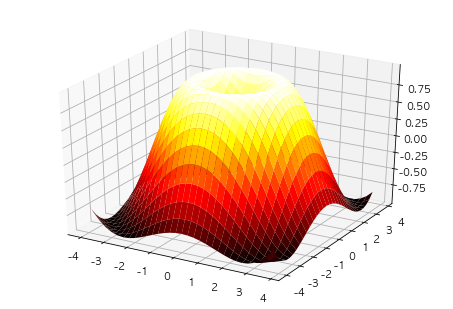

```python
fig = plt.figure()
ax = Axes3D(fig)
ax.plot_surface(XX, YY, ZZ, rstride=1, cstride=1, cmap='hot')
plt.show()
```

### subplot에 대해 좀 더 알아 보도록 하자.

[figure not shown]

- `(fig, axes) = plt.subplots()`
  - **모든 subplot에 대한 axe를 한꺼번에 생성**
- `axe = plt.subplot()`
- `axe = fig.add_subplot()`

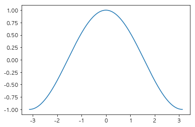

```python
x = np.linspace(-np.pi, np.pi, 256, endpoint=True)
y = np.cos(x)

f, ax = plt.subplots()
ax.plot(x, y)
plt.show()
```

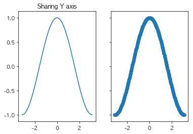

```python
# sharey=True → y tick 공유
f, (ax1, ax2) = plt.subplots(1, 2, sharey=True)
ax1.plot(x, y)
ax1.set_title('Sharing Y axis')
ax2.scatter(x, y)
plt.show()
```

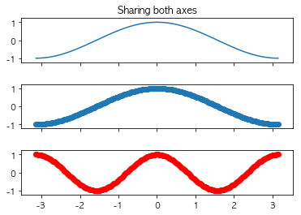

```python
# sharex=True, sharey=True → x, y tick 공유

f, (ax1, ax2, ax3) = plt.subplots(3, sharex=True, sharey=True)
ax1.plot(x, y)
ax1.set_title('Sharing both axes')
ax2.scatter(x, y)
ax3.scatter(x, 2 * y ** 2 - 1, color='r')
f.subplots_adjust(hspace=0.5)
plt.setp([a.get_xticklabels() for a in f.axes[:-1]], visible=False);
plt.show()
```

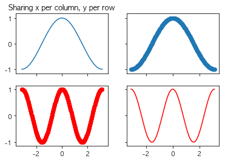

```python
# subplot의 축이 아래와 같이 컬럼, 로우끼리 공유하고 싶을 때
f, ((ax1, ax2), (ax3, ax4)) = plt.subplots(2, 2, sharex='col', sharey='row')
ax1.plot(x, y)
ax1.set_title('Sharing x per column, y per row')
ax2.scatter(x, y)
ax3.scatter(x, 2 * y ** 2 - 1, color='r')
ax4.plot(x, 2 * y ** 2 - 1, color='r')
plt.show()
```

#### `ax = plt.subplot( )`

- 순차적으로 subplot 생성

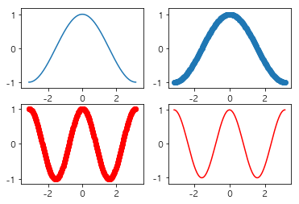

```python
# subplot을 순차적으로 그리는 방법

ax1 = plt.subplot(221)
plt.plot(x, y)


ax2 = plt.subplot(2,2,2, sharey=ax1)
plt.scatter(x, y)

ax3 = plt.subplot(2,2,3, sharex=ax1)
plt.scatter(x, 2 * y ** 2 - 1, color='r')

ax4 = plt.subplot(2,2,4, sharex=ax2, sharey=ax1)

plt.plot(x, 2 * y ** 2 - 1, color='r')
plt.show()
```

#### `ax = fig.add_subplot( )`

- 순차적으로 subplot 생성

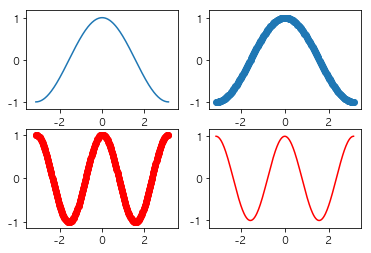

```python
# subplot을 순차적으로 그리는 방법

fig = plt.figure()
ax1 = fig.add_subplot(221)
plt.plot(x, y)

ax2 = fig.add_subplot(2,2,2, sharey=ax1)
plt.scatter(x, y)

ax3 = fig.add_subplot(2,2,3, sharex=ax1)
plt.scatter(x, 2 * y ** 2 - 1, color='r')

ax4 = fig.add_subplot(2,2,4, sharex=ax2, sharey=ax1)
plt.plot(x, 2 * y ** 2 - 1, color='r')

plt.show()
```

> Share this on → [Tweet](https://twitter.com/share)

#### Related Posts

- [Visualization with Python - seaborn](http://localhost:4000/seaborn/visualization/2017/10/07/visualization_2/) (Categories: seaborn, visualization)
- [Visualization with Python - matplotlib ③](http://localhost:4000/matplotlib/visualization/2017/10/07/visualization_1/) (Categories: matplotlib, visualization)
- [Visualization with Python - matplotlib ①](http://localhost:4000/matplotlib/visualization/2017/10/06/visualization/) (Categories: matplotlib, visualization)

> « Visualization with Python - matplotlib ① Visualization with Python - matplotlib ③ »